# 키와 흡연의 상관관계

윤창일

## 서론

이 분석에서는 심장병을 앓고 있는 환자군에서 키와 흡연의 상관관계를 살펴본다. 키에서 오는 사회적 심리적 요인이 개인으로 하여금 흡연을 하도록 만드는지, 그것이 다시 심장병으로 연결되는지에 대한 개략적인 분석이다. 그 외에도 BMI와 흡연의 관계, 비만-키-나이 의 관계를 3차원적으로 살펴본다.

## 방법

키와 흡연 : 비척도와 순위척도 > boxplot BMI와 흡연 : 비척도와 순위척도 > boxplot 키와 BMI : 비척도와 비척도 > scatterplot 키-BMI-나이 : 비척도 > scatter 3D TC-TG-HDLC-LDLC-BMI : 비척도 > plotfaces

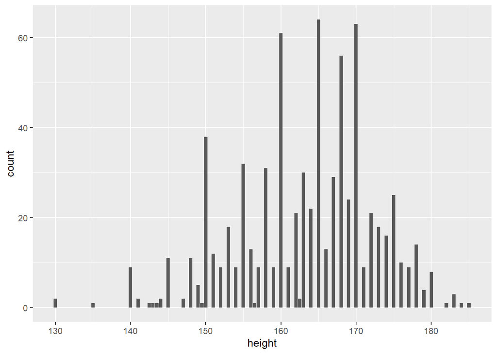

```r
library(ggplot2)
library(readxl)
library(tidyverse)
library(scales)
library(dplyr)
library(tinytex)
library(plot3D)
library(DescTools)
setwd("C:/Users/cmc/Desktop/intern assignment/스트레스와 흡연율의 관계를 통한 키와 스트레스의 상관관계")
acs <- read.csv("C:/Users/cmc/Desktop/intern assignment/acs.csv")


##whole data height distribution wtout NA
acs.hcleanse<- acs %>% drop_na(height)

ggplot(data=acs.hcleanse)+geom_bar(mapping=aes(x=height))
```

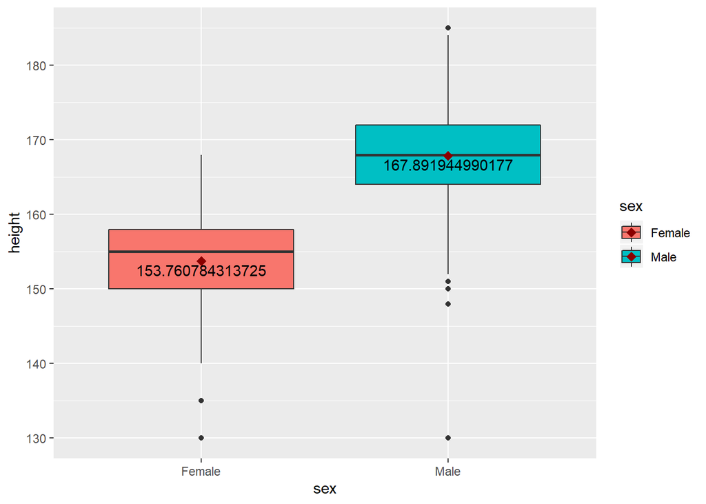

```r
macs<- acs.hcleanse %>% filter((sex=="Male"))
facs<- acs.hcleanse %>% filter((sex=="Female"))


##남녀로 구분한 키의 boxplot
hmeans<-aggregate(height ~ sex, acs.hcleanse, mean)

ggplot(data=acs.hcleanse)+geom_boxplot(aes(y=height , x=sex, fill=sex))+stat_summary(aes(sex,height), fun.y=mean, colour="darkred", geom="point",shape=18, size=3, show.legend = TRUE) + geom_text(data = hmeans, aes(x=sex, label = height,  y = height - 1.2))
```

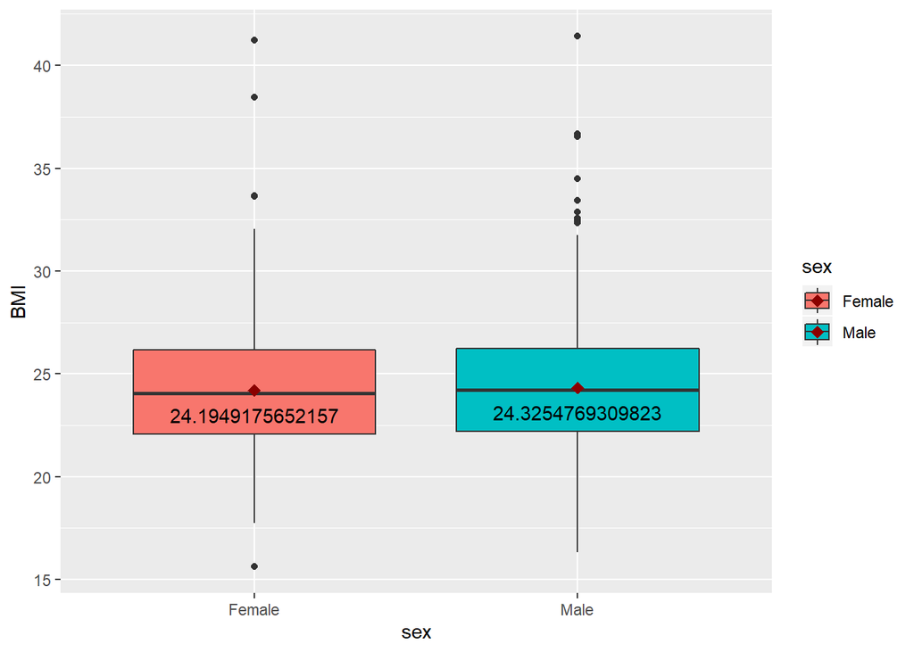

```r
##남녀로 구분한 BMI의 boxplot
acs.BMIcleanse<- acs %>% drop_na(BMI)
Bmeans<-aggregate(BMI ~ sex, acs.BMIcleanse, mean)

ggplot(data=acs.BMIcleanse)+geom_boxplot(mapping=aes(y=BMI , x=sex, fill=sex))+stat_summary(aes(sex,BMI), fun.y=mean, colour="darkred", geom="point",shape=18, size=3, show.legend = TRUE) + geom_text(data = Bmeans, aes(x=sex, label = BMI,  y = BMI - 1.2))
```

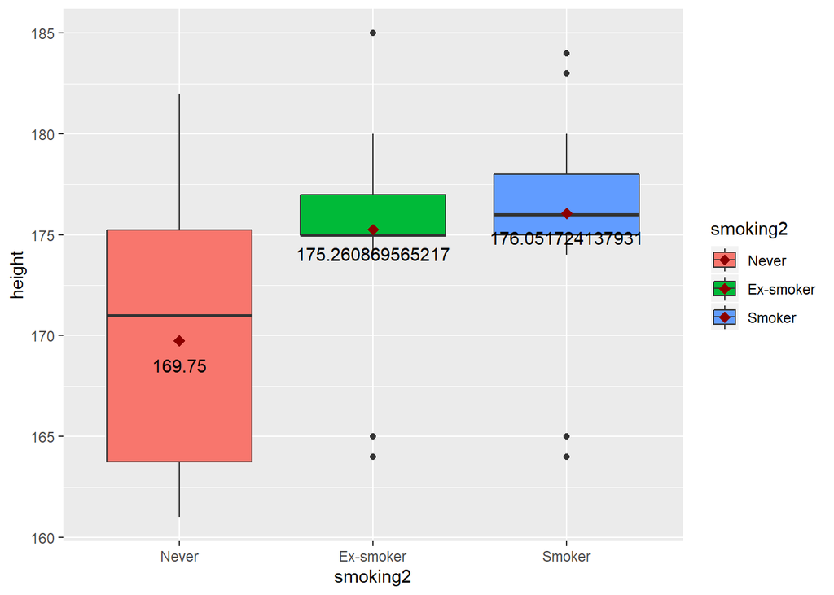

```r
##본격 분석그래프 작성
##divided data height distribution
tacs<- acs.hcleanse %>%  filter((height>=174 & sex=="Male") | (height>=161 & sex=="Female"))
sacs<- acs.hcleanse %>%  filter((height<174 & sex=="Male") | (height<161 & sex=="Female"))

##Never, Ex-smoker 순서 바꿔서 boxplot 그리기
tacs$smoking2<-factor(tacs$smoking,levels=levels(tacs$smoking)<-c("Never","Ex-smoker","Smoker"))
sacs$smoking2<-factor(sacs$smoking,levels=levels(sacs$smoking)<-c("Never","Ex-smoker","Smoker"))

levels(tacs$smoking)<-c("Ex-smoker","Never","Smoker")
levels(sacs$smoking)<-c("Ex-smoker","Never","Smoker")

thmeans<-aggregate(height ~ smoking2, tacs, mean)
shmeans<-aggregate(height ~ smoking2, sacs, mean)

ggplot(data=tacs)+geom_boxplot(mapping=aes(x=smoking2,y=height, fill=smoking2))+stat_summary(aes(smoking2,height), fun.y=mean, colour="darkred", geom="point",shape=18, size=3, show.legend = TRUE) + geom_text(data = thmeans, aes(x=smoking2, label = height,  y = height - 1.2))
```

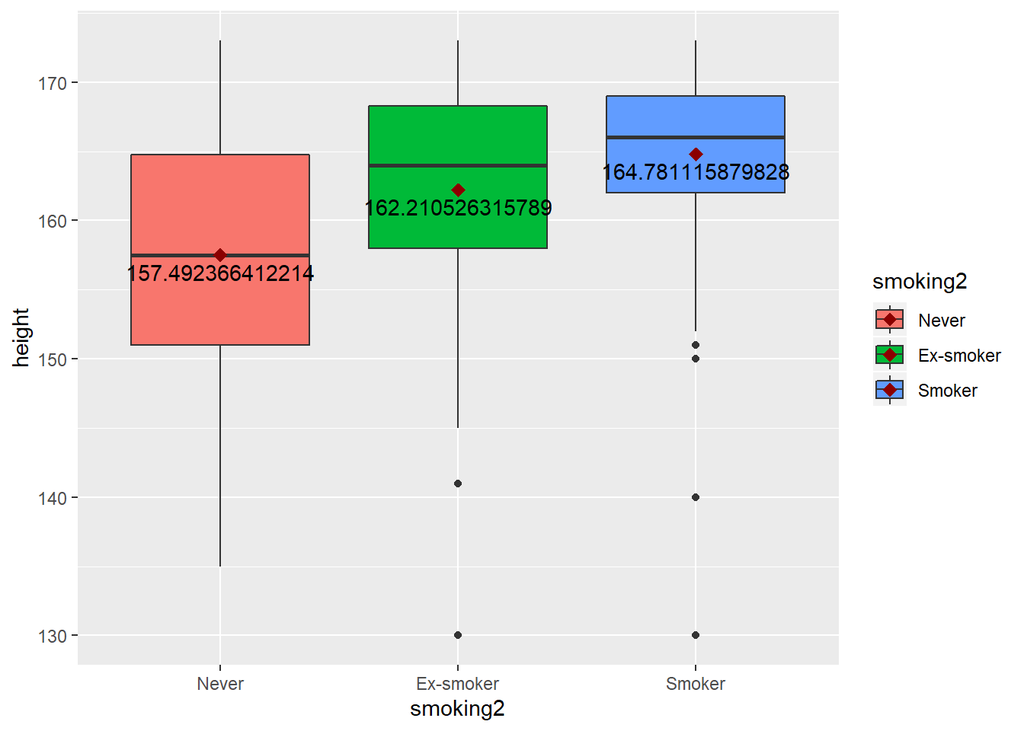

```r
ggplot(data=sacs)+geom_boxplot(mapping=aes(x=smoking2,y=height, fill=smoking2))+stat_summary(aes(smoking2,height), fun.y=mean, colour="darkred", geom="point",shape=18, size=3, show.legend = TRUE) + geom_text(data = shmeans, aes(x=smoking2, label = height,  y = height - 1.2))
```

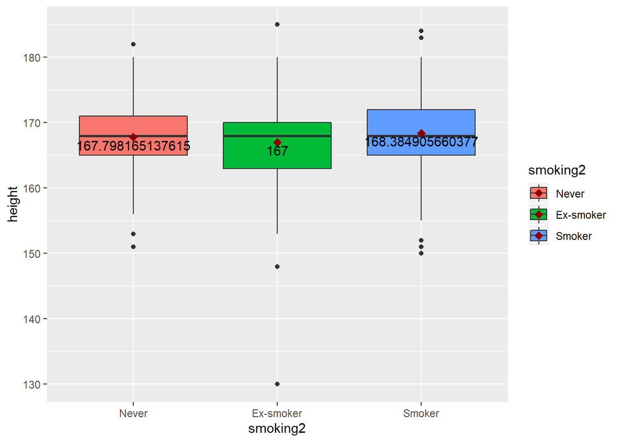

```r
##이성간에 차이가 있는 것은 아닐까해서 성별로 나눈 비교
macs$smoking2<-factor(macs$smoking,levels=levels(macs$smoking)<-c("Never","Ex-smoker","Smoker"))
facs$smoking2<-factor(facs$smoking,levels=levels(facs$smoking)<-c("Never","Ex-smoker","Smoker"))
mmeans<-aggregate(height ~ smoking2, macs, mean)
fmeans<-aggregate(height ~ smoking2, facs, mean)

ggplot(data=macs)+geom_boxplot(mapping=aes(x=smoking2,y=height, fill=smoking2))+stat_summary(aes(smoking2,height), fun.y=mean, colour="darkred", geom="point",shape=18, size=3, show.legend = TRUE) + geom_text(data = mmeans, aes(x=smoking2, label = height,  y = height - 1.2))
```

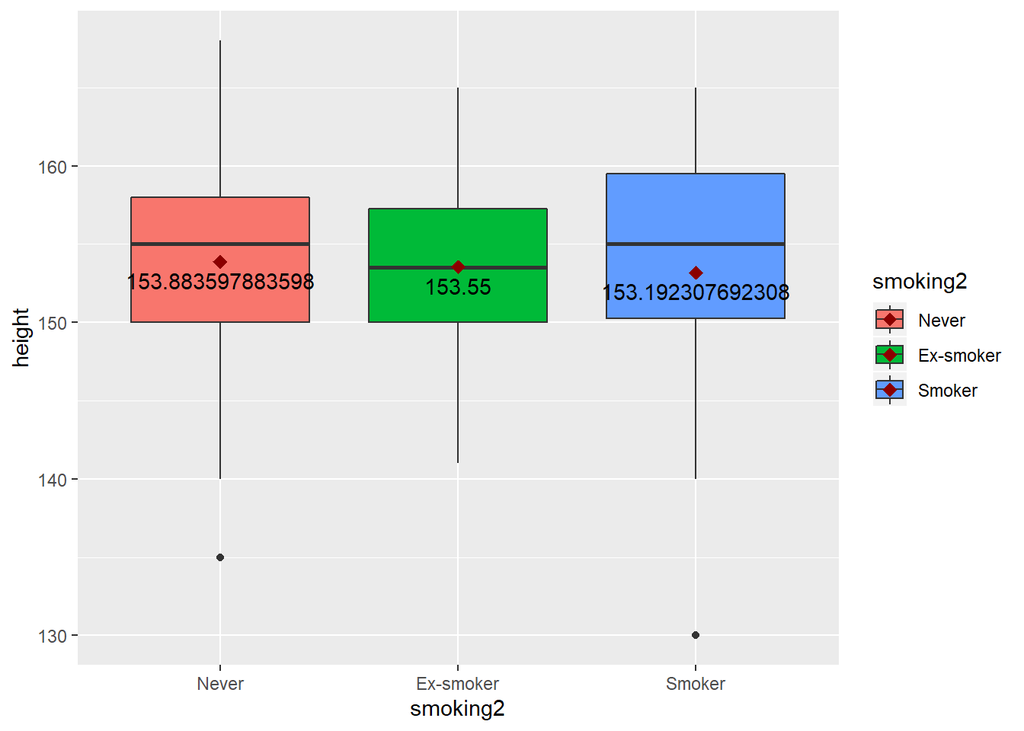

```r
ggplot(data=facs)+geom_boxplot(mapping=aes(x=smoking2,y=height, fill=smoking2))+stat_summary(aes(smoking2,height), fun.y=mean, colour="darkred", geom="point",shape=18, size=3, show.legend = TRUE) + geom_text(data = fmeans, aes(x=smoking2, label = height,  y = height - 1.2))
```

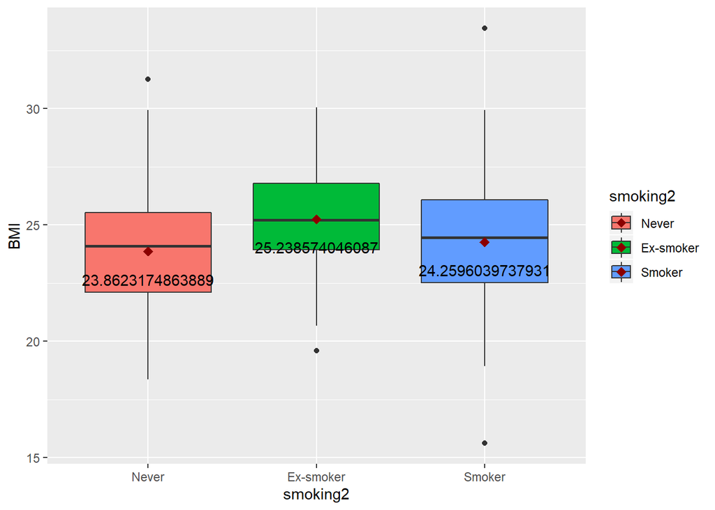

```r
##BMI로 boxplot 그리기
tBmeans<-aggregate(BMI ~ smoking2, tacs, mean)
sBmeans<-aggregate(BMI ~ smoking2, sacs, mean)

ggplot(data=tacs)+geom_boxplot(mapping=aes(x=smoking2,y=BMI, fill=smoking2)) +stat_summary(aes(smoking2,BMI), fun.y=mean, colour="darkred", geom="point",shape=18, size=3, show.legend = TRUE) + geom_text(data = tBmeans, aes(x=smoking2, label = BMI,  y = BMI - 1.2))
```

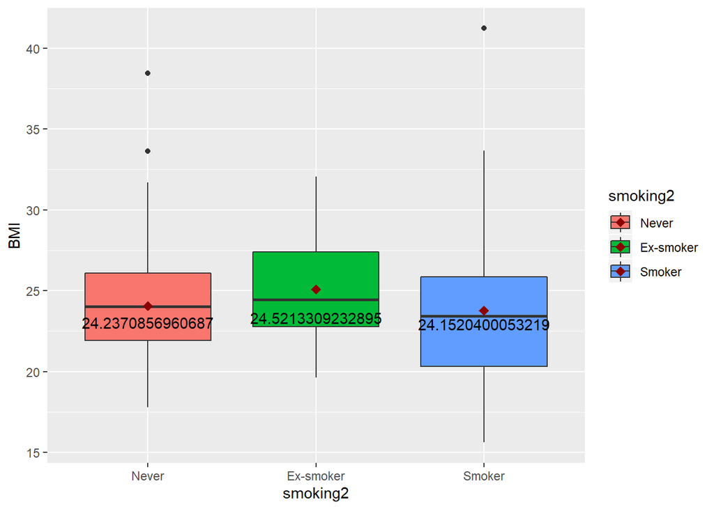

```r
ggplot(data=facs)+geom_boxplot(mapping=aes(x=smoking2,y=BMI, fill=smoking2))+stat_summary(aes(smoking2,BMI), fun.y=mean, colour="darkred", geom="point",shape=18, size=3, show.legend = TRUE) + geom_text(data = sBmeans, aes(x=smoking2, label = BMI,  y = BMI - 1.2))
```

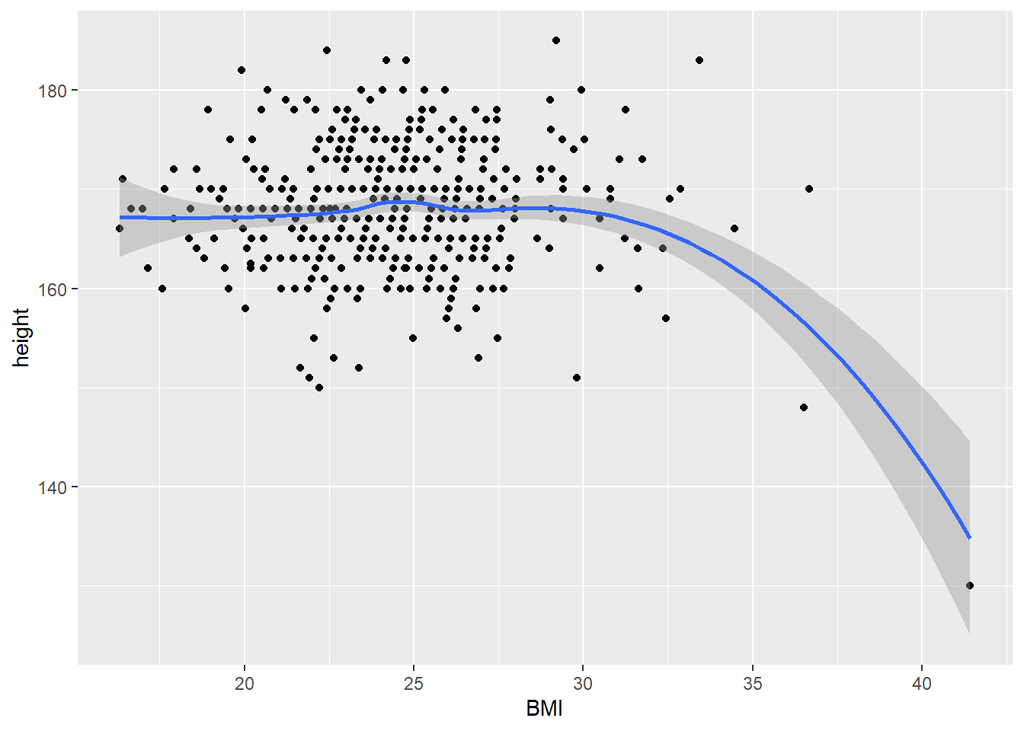

```r
##point와 smooth를 활용하여 키-BMI 그래프 그리기
ggplot(data=macs, aes(BMI, height))+geom_point()+geom_smooth(method="auto")
```

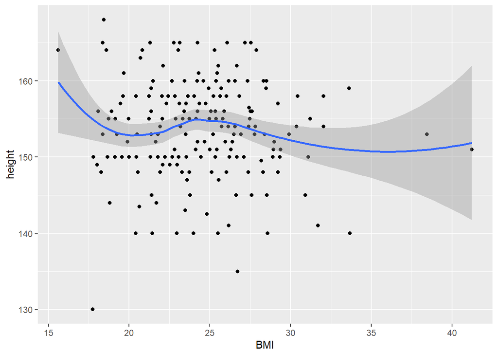

```r
ggplot(data=facs, aes(BMI, height))+geom_point()+geom_smooth(method="auto")
```

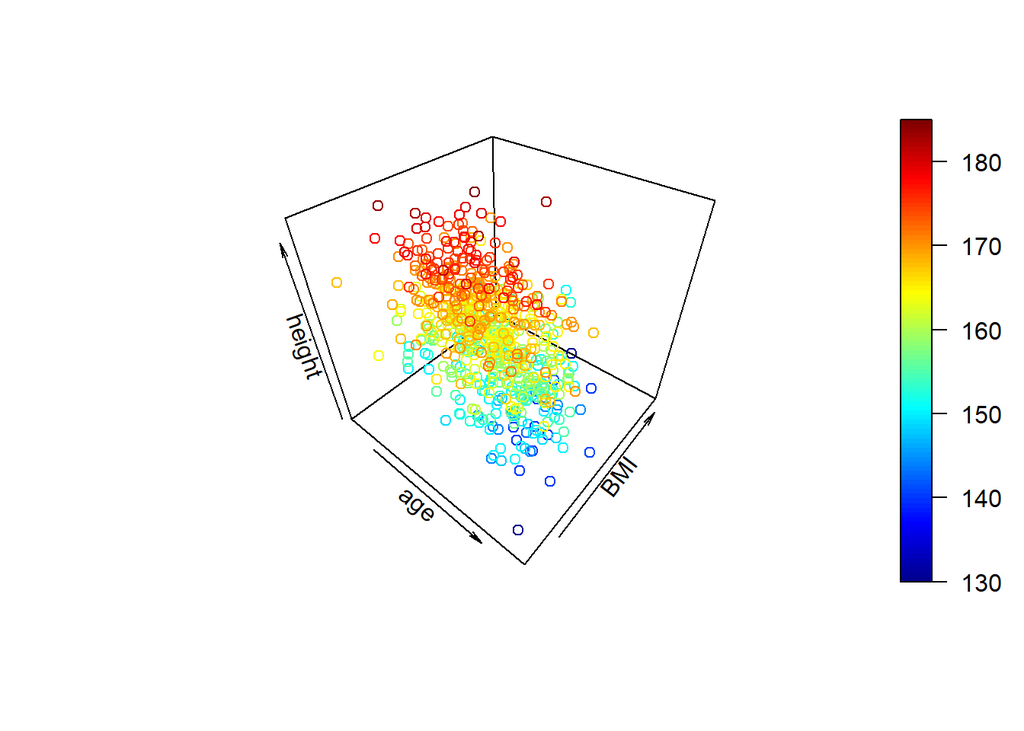

```r
##scatter3D()를 활용해서 키 나이 BMI 를 비교한 그래프를 그리기
##scatter3D(data=acs.cleanse, "age", "BMI", "height")
acs.allcleanse<- acs %>% drop_na()

scatter3D(x=acs.allcleanse$age, y=acs.allcleanse$BMI, z=acs.allcleanse$height, xlab="age",ylab="BMI",zlab="height")
```

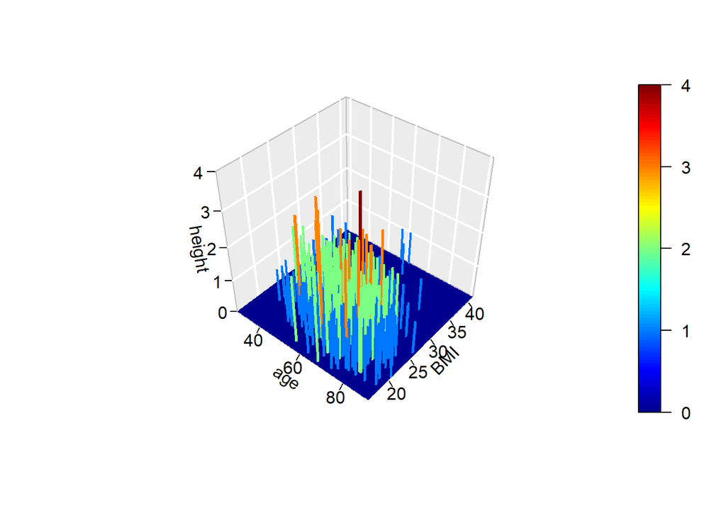

```r
##hist3D()를 활용해서 그리기
x_breaks <- seq(min(acs.allcleanse$age), max(acs.allcleanse$age), length.out = 100)
y_breaks <- seq(min(acs.allcleanse$BMI), max(acs.allcleanse$BMI), length.out = 100)
x_values <- 0.5*(x_breaks[-1]+x_breaks[-length(x_breaks)])
y_values <- 0.5*(y_breaks[-1]+y_breaks[-length(y_breaks)])
z_values <- table(cut(acs.allcleanse$age, x_breaks), cut(acs.allcleanse$BMI, y_breaks))

hist3D(x=x_values, y=y_values, z=z_values, xlab="age",ylab="BMI",zlab="height", bty="g", ticktype="detailed", d=3)
```

```r
##멋있는 그래프로 마무리 plotfaces()
##1)데이터 정제
acs.TCcleanse<- acs %>% drop_na(TC)
mTC<- acs.TCcleanse %>% filter((sex=="Male"))
fTC<- acs.TCcleanse %>% filter((sex=="Female"))
tTC<- acs.TCcleanse %>%  filter((height>=174 & sex=="Male") | (height>=161 & sex=="Female"))
sTC<- acs.TCcleanse %>%  filter((height<174 & sex=="Male") | (height<161 & sex=="Female"))

acs.TGcleanse<- acs %>% drop_na(TG)
mTG<- acs.TGcleanse %>% filter((sex=="Male"))
fTG<- acs.TGcleanse %>% filter((sex=="Female"))
tTG<- acs.TGcleanse %>%  filter((height>=174 & sex=="Male") | (height>=161 & sex=="Female"))
sTG<- acs.TGcleanse %>%  filter((height<174 & sex=="Male") | (height<161 & sex=="Female"))

acs.HDLCcleanse<- acs %>% drop_na(HDLC)
mHDLC<- acs.HDLCcleanse %>% filter((sex=="Male"))
fHDLC<- acs.HDLCcleanse %>% filter((sex=="Female"))
tHDLC<- acs.HDLCcleanse %>%  filter((height>=174 & sex=="Male") | (height>=161 & sex=="Female"))
sHDLC<- acs.HDLCcleanse %>%  filter((height<174 & sex=="Male") | (height<161 & sex=="Female"))

acs.LDLCcleanse<- acs %>% drop_na(LDLC)
mLDLC<- acs.LDLCcleanse %>% filter((sex=="Male"))
fLDLC<- acs.LDLCcleanse %>% filter((sex=="Female"))
tLDLC<- acs.LDLCcleanse %>%  filter((height>=174 & sex=="Male") | (height>=161 & sex=="Female"))
sLDLC<- acs.LDLCcleanse %>%  filter((height<174 & sex=="Male") | (height<161 & sex=="Female"))

acs.BMIcleanse<- acs %>% drop_na(BMI)
mBMI<- acs.BMIcleanse %>% filter((sex=="Male"))
fBMI<- acs.BMIcleanse %>% filter((sex=="Female"))
tBMI<- acs.BMIcleanse %>%  filter((height>=174 & sex=="Male") | (height>=161 & sex=="Female"))
sBMI<- acs.BMIcleanse %>%  filter((height<174 & sex=="Male") | (height<161 & sex=="Female"))





HumanRace<- matrix(c(mean(acs.TCcleanse$TC),mean(mTC$TC),mean(fTC$TC),mean(tTC$TC),mean(sTC$TC),mean(acs.TGcleanse$TG),mean(mTG$TG),mean(fTG$TG),mean(tTG$TG),mean(sTG$TG),mean(acs.HDLCcleanse$HDLC),mean(mHDLC$HDLC),mean(fHDLC$HDLC),mean(tHDLC$HDLC),mean(sHDLC$HDLC),mean(acs.LDLCcleanse$LDLC),mean(mLDLC$LDLC),mean(fLDLC$LDLC),mean(tLDLC$LDLC),mean(sLDLC$LDLC),mean(acs.BMIcleanse$BMI),mean(mBMI$BMI),mean(fBMI$BMI),mean(tBMI$BMI),mean(sBMI$BMI)), ncol=5)
colnames(HumanRace)<-c('TC', 'TG', 'HDLC', 'LDLC', 'BMI')
rownames(HumanRace)<-c('남녀전체','남','여', '평균이상','평균이하')
HumanRace.table<-as.table(HumanRace)
HumanRace.table
```

```
##                 TC        TG      HDLC      LDLC       BMI
## 남녀전체 185.20024 125.23872  38.23501 116.58343  24.28190
## 남       183.33788 127.88078  37.84022 116.00000  24.32548
## 여       188.94513 119.93571  39.02888 117.76087  24.19492
## 평균이상 191.13739 136.59483  37.60000 119.25217  24.32981
## 평균이하 185.88352 124.85202  38.45055 117.55503  24.27324
```

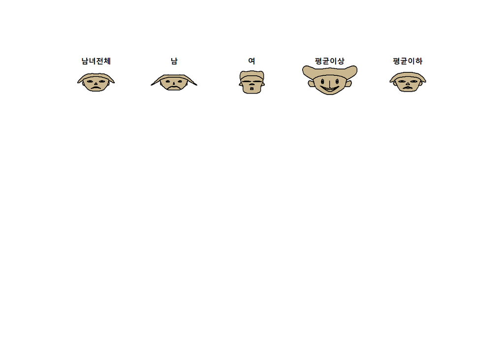

```r
PlotFaces(HumanRace.table, 1:5, fill = FALSE, nr=5, nc=5, scale = TRUE, byrow = FALSE, labels=c('남녀전체','남','여', '평균이상','평균이하'), col=hecru)
```